# Questions May25

### How does Revigo take the GO values and P values to get the results? What is the relationship between these two values?

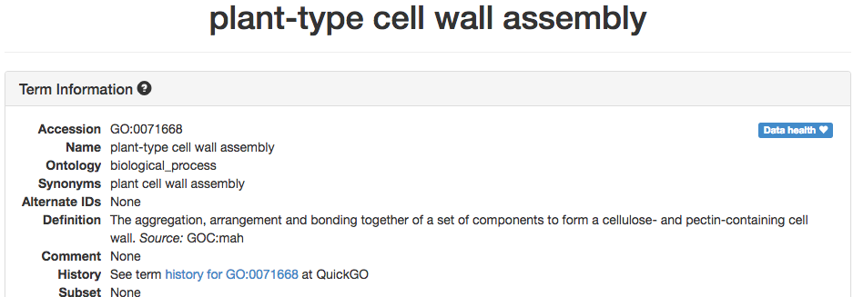

- The GO values are identifiers for specific ontology terms
- The p-values are whether specific GO terms are over-represented in our gene list

### How does Revigo take the GO values and P values to get the results? What is the relationship between these two values?

- The GO values are identifiers for specific ontology terms
- The p-values are whether specific GO terms are over-represented in our gene list

### Can you go over the TreeMap in REVIGO?

[figure not shown]

### Are there any other ways to test if genes are differentially expressed other than the ones discussed in class? / What is the difference between DESeq and edgeR? When would you use one over the other?

There are many different programs that do this. See http://rnajournal.cshlp.org/content/22/6/839.long for a comparison of nine of the most popular ones.

### I noticed the webpage with the motif information included the genomic sequence, and that some of the motifs had similar sequences. Although there was a motif that had the most enrichment, wouldn't it be possible for other motifs with a similar sequence to also be highly enriched? What could account for the difference of enrichment if the genomic sequences are so similar (assuming the function is also similar)?

Yes, multiple could be enriched

But…1bp mismatch really can make a difference…

### List some common mistakes in the experiments, and what are ways to fix them?

- *library mixup / mislabelling.* This can be detected on the BCV plot and maybe fixed by sample swap…
- *poor experimental design.* Be sure to use proper randomization and blocking protocols.
- *poor library prep* Practice!

### How do you plot multiple variables in a histogram without melting?

Use a for loop to loop through the column names

```r
madeUpData <- as.data.frame(matrix(rnorm(600,mean = 10),ncol=6,dimnames=list(NULL,LETTERS[1:6])))
round(head(madeUpData),2)
```

```
      A     B     C     D     E     F
1  8.66 10.52 10.04  9.37 10.60 11.02
2  8.06 12.04 10.00  8.93  8.54  8.43
3  8.55  8.90 10.81 10.45  9.73 10.32
4  9.42 11.38  8.91  8.84  9.80 10.43
5  9.14 10.23  9.31 11.46 11.02  9.99
6 10.99  9.29  8.42  9.30  8.72  9.61
```

### How do you plot multiple variables in a histogram without melting?

Use a for loop to loop through the column names

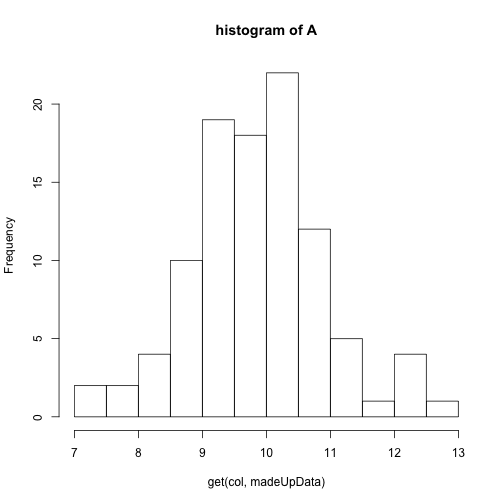

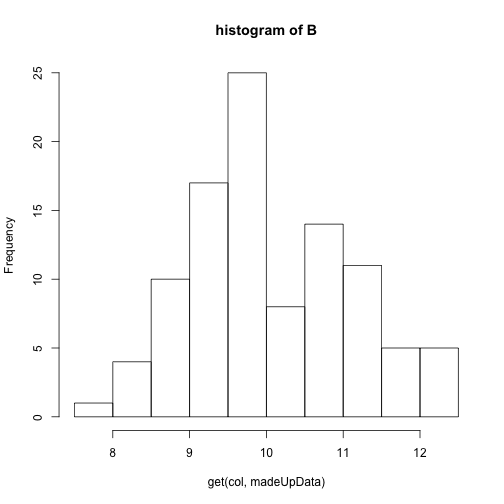

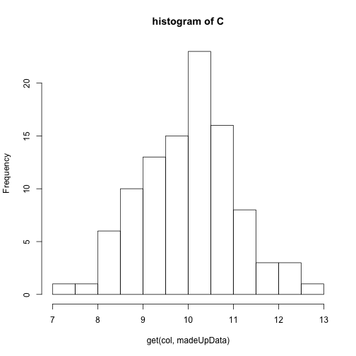

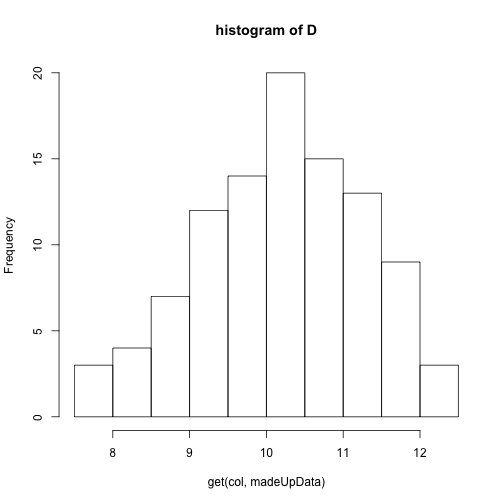

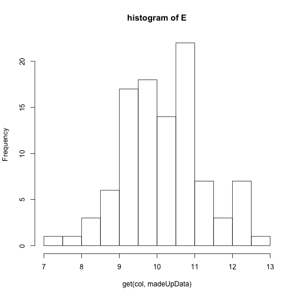

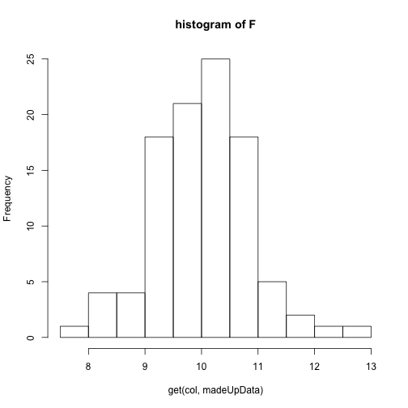

```r
for(col in colnames(madeUpData))
  hist(get(col,madeUpData),main=paste("histogram of",col))
```

### What is the difference between read.table vs read.delim? When can each be used?

`read.table` is a generic method for importing spreadsheets and you have to specify many of the options (like what the delimiter is).

`read.delim` essentially calls `read.table` but with options already filled in for a tab-delimited file.

`read.csv` essentially calls `read.table` but with options already filled in for a comma-delimited file.

### For assignment 6, part 1, question 8a, how do you interpret the MDS plot?

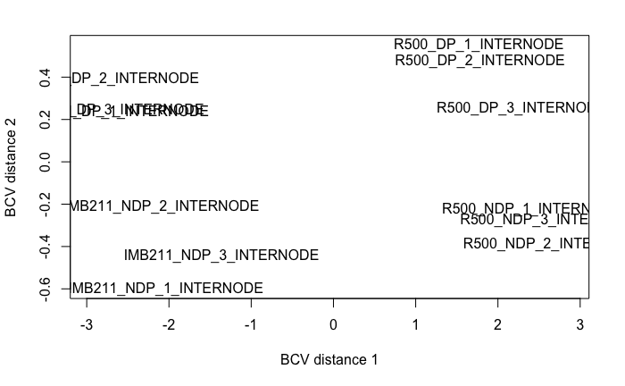

- This plot shows the two main components of variation among samples.
- Samples that are closer together have more similar expression.
- So we hope that replicates are close and that conditions/treatments separate samples.

### For assignment 6, part 1, question 8a, how do you interpret the MDS plot?

(repeat text in case cutoff on previous slide)

- This plot shows the two main components of variation among samples.
- Samples that are closer together have more similar expression.
- So we hope that replicates are close and that conditions/treatments separate samples.

### For assignment 6, I don't understand how to read the dispersion plot and what it means?

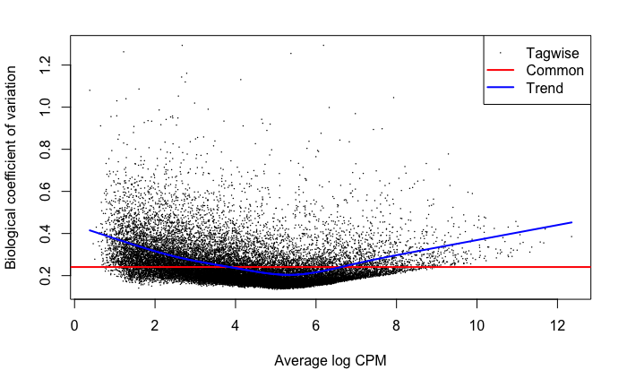

### In what context would it be appropriate to use RPKM?

NEVER!

Just kidding…for visualization, especially if trying to compare between genes.

### Could you briefly explain the difference between p-value and false discovery rate, and why FDR is preferred in the labs we're doing

- This goes back to multiple testing. We are testing differnetial expression of 30,000 genes.
- Thought experiment: Take 6 replicates of the same genotype and treatment (say R500 in NDP) and arbitrarily split them into two groups and test for differential expression
- How many genes would be significant at 0.05?
- 30000 * 0.05 = 1,500!
- FDR corrects for this.
- FDR of 0.05 means that 5% of the genes at this significance level are expected to be false positives.

### what does the 'sort=' argument do in merge() function

Try it both ways and look at the result!

Or read the help!

### Can you walk us through the coding or explain how the coding works for the dispersion models/ finding top 10 genes, etc? (assignment 6.1)

### How is the genotype x treatment term in the last exercise of Assignment 6 Part 1 created?

### Can you explain how the TMM normalization method works?

I will try to put something together for Tuesday